# SFBay native oyster survival analyses

Karina J. Nielsen

Last compiled on 19 May 2021

# 1 Question of interest

Do juvenile native oysters in San Francisco Bay survive better when they have rockweed *Fucus distichus* cover (+/-) Does the effect, if any, vary with tidal height (low vs. high)?

# 2 Methods summary

Juvenile *Ostrea lurida* were super-glued to individually labeled porcelain tiles and attached to rocks in the intertidal zone with marine epoxy putty. We established ten plots of ten oysters each with and without *Fucus* cover in the high and low intertidal zones.

Oyster plots were established on January 19, 2020. We surveyed the plots every two weeks until May 2, 2020 when we terminated the experiment for all but two plots we inadvertently missed. We terminated these two plots on June 11, 2020. We missed one survey in mid-March due to the pandemic stay at home health order.

For each survey, we noted the condition of each oyster and photographed the plots. We noted whether or not the tile, label, or oyster was missing. We also noted if the oyster was alive or if it was dead with some shell remaining.

Data were entered in an Excel spreadsheet and then tidied and analyzed using R Statistical Software version 4.0X, R Core Team (2020). Time intervals were calculated to determine days elapsed from the beginning of deployment to the last follow-up time for each individual oyster. The data were right-censored unless a dead oyster (shell present) was observed.

# 3 Survival analyses

We used the survival package Therneau T (2020) to calculate survival curves with the Kaplan-Meier method. A log-rank chi-squared test was used to assess differences among the curves. We also fit Cox proportional hazards regression model.

## 3.1 Kaplan-Meier survivorship analysis

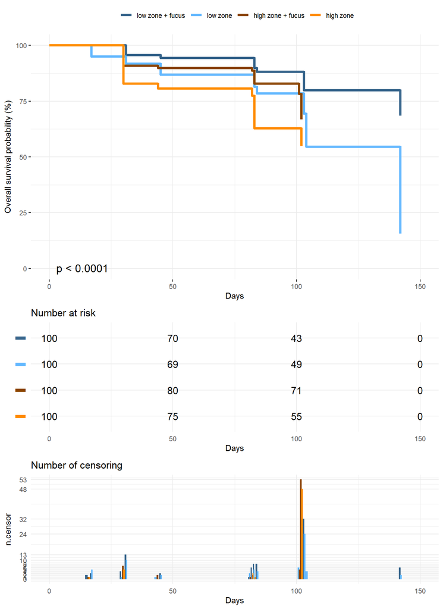

## 3.2 Cox proportional hazards analysis

### 3.2.1 Table

| Characteristic | HR1 | 95% CI1 | p-value |
| --- | --- | --- | --- |
| zone |  |  | <0.001 |
| low | — | — |  |
| high | 3.03 | 1.53, 6.01 |  |
| fucus |  |  | 0.009 |
| fucus | — | — |  |
| bare | 2.25 | 1.19, 4.24 |  |
| zone * fucus |  |  | 0.4 |
| high * bare | 0.71 | 0.32, 1.57 |  |

1HR = Hazard Ratio, CI = Confidence Interval

### 3.2.2 Forest plot

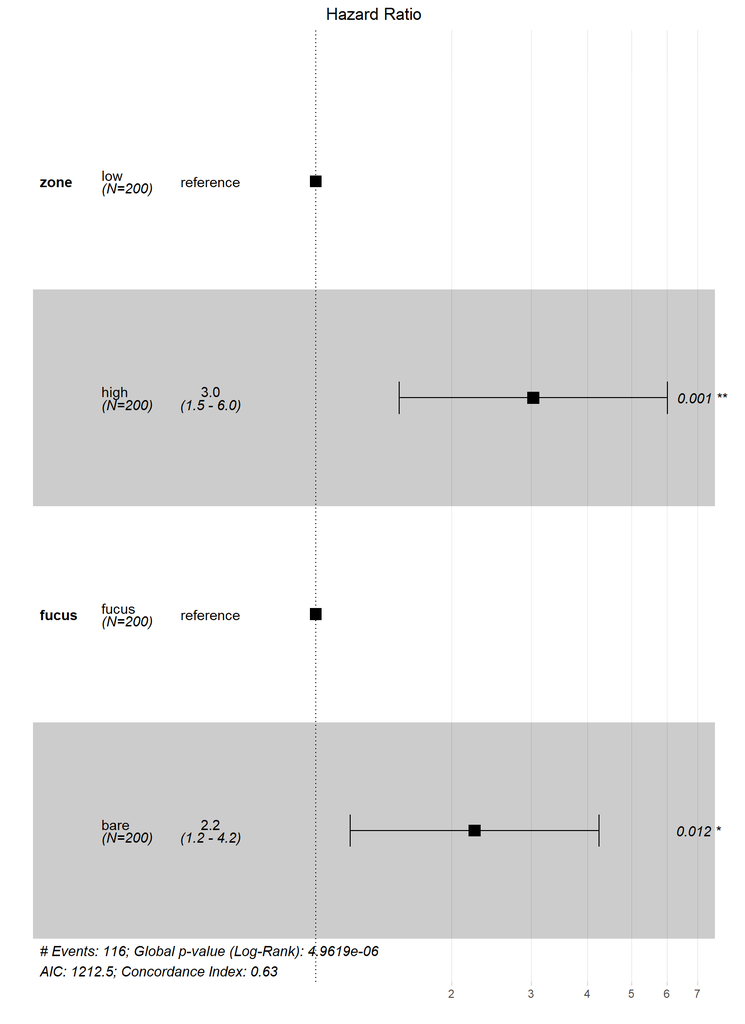

## 3.3 Oysters with known fates - proportion surviving

For all oysters that had a known fate at the end of the field experiment (i.e., persisted alive until the end, or died, leaving behind some shell on the tile), we calculated the proportion of these that survived in each plot for each of the four unique treatment combinations (zone (low/high) x fucus (+/-)). We present these as box plots. We also indicate the plots in the high zone that appeared to benefit from some shading from adjacent trees at the edge of the upper intertidal zone.

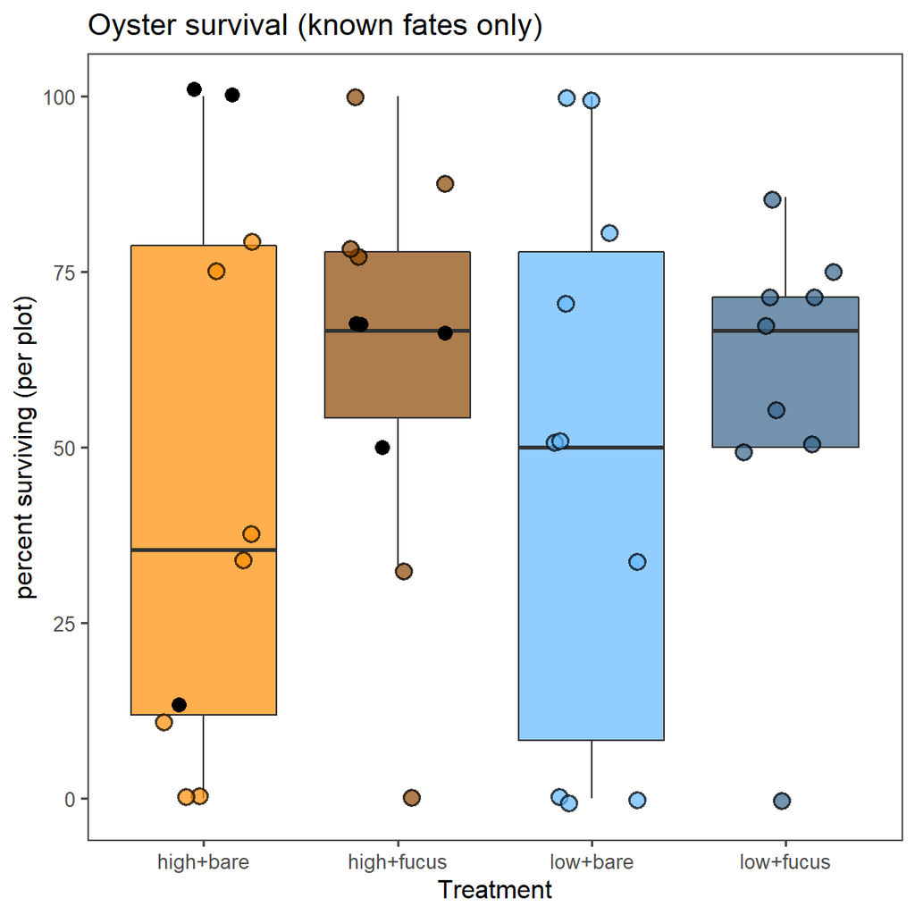